# Table of results and venn diagrams

L Collado-Torres

20 February 2016

# Contents

This report creates the CSV files with the candidate differentially expressed regions (DERs) found using `derfinder` ([Collado-Torres, Frazee, Love, Irizarry, et al., 2015](http://www.biorxiv.org/content/early/2015/02/19/015370.abstract)) via the single-base level approach on the *Snyder* and *Hippo* data sets. It also has Venn diagrams illustrating the overlap with known annotation.

# 1 Results

## 1.1 Generate CSV files

The following code shows how to generate the CSV files from the `R` objects.

```r
## Setup
suppressMessages(library("GenomicRanges"))
suppressMessages(library("derfinder"))
suppressMessages(library("derfinderPlot"))

## Experiments
exps <- c('snyder', 'hippo')

## Find the latest run from each experiment
run <- sapply(exps, function(exp) {
    runs <- dir(file.path('..', exp, 'derAnalysis'), pattern = 'run')
    runs[length(runs)]
})

## Load regions and annotation data
regions <- lapply(exps, function(exp) {
    load(file.path('..', exp, 'derAnalysis', run[exp], 'fullRegions.Rdata'))
    res <- fullRegions
    names(res) <- seq_len(length(res))
    return(res)
})

anno <- lapply(exps, function(exp) {
    load(file.path('..', exp, 'derAnalysis', run[exp],
        'fullAnnotatedRegions.Rdata'))

    ## Fix region labels: its intergenic, not intragenic
    if('intragenic' %in% names(fullAnnotatedRegions$countTable)) {
        ## Fix countTable
        names(fullAnnotatedRegions$countTable)[names(fullAnnotatedRegions$countTable) == 'intragenic'] <- 'intergenic'
    }
    res <- fullAnnotatedRegions
    return(res)
})

## Fix names
names(regions) <- names(anno) <- exps

## Perform check and create csv files
check <- vector("list", length(exps))
names(check) <- exps
for(exp in exps) {

    ## Peform check
    check[[exp]] <- identical(nrow(anno[[exp]]$countTable),
        length(regions[[exp]]))

    ## Export regions information into plain text
    write.csv(as.data.frame(regions[[exp]]), file = paste0("supplementaryFile",
        which(exp == exps), ".csv"), quote = FALSE, row.names = FALSE)

    ## You can later read them in R using:
    # read.csv("supplementaryFile1.csv")
    # read.csv("supplementaryFile2.csv")

    ## Compress
    system(paste0('gzip supplementaryFile', which(exp == exps), '.csv'))
}

## Check that the rows match
unlist(check)
```

```
## snyder  hippo
##   TRUE   TRUE
```

CSV files correspond to experiments snyder, hippo from runs run3-v1.0.10, run3-v1.0.10 respectively.

## 1.2 Venn diagrams

The following Venn diagrams show how many candidate differentially expressed regions (DERs) overlap with an exon, intron, or intergenic regions of the UCSC hg19 knownGene annotation. By default, a minimum overlap of 20 base pairs is required to say that a candidate DER overlaps any of feature. The annotation overlap was done using the `mergeResults()` function from `derfinder` ([Collado-Torres, Frazee, Love, Irizarry, et al., 2015](http://www.biorxiv.org/content/early/2015/02/19/015370.abstract)) while the Venn diagrams were made using `derfinderPlot` ([Collado-Torres, Jaffe, and Leek, 2015](http://www.bioconductor.org/packages/release/bioc/html/derfinderPlot.html)).

A maximum of three Venn diagrams are shown per data set. The first one uses all the candidate DERs, the second one uses only the candidate DERs that had a significant q-value (by default less than 0.10), and the third uses only the candidate DERs that had a FWER adjusted p-value less than 0.05.

```r
for(exp in exps) {
    ## Using all candidate DERs
    vennRegions(anno[[exp]], main=paste("\n", exp, "using UCSC.hg19.knownGene"),
        counts.col="blue")

    ## Using candidate DERs with a significant q-value
    if(sum(regions[[exp]]$significantQval == "TRUE") > 0)
    vennRegions(anno[[exp]], regions[[exp]]$significantQval == "TRUE",
        main=paste("\n\n", exp, "using UCSC.hg19.knownGene\nRestricted to significant q-value candidate DERs"),
        counts.col = "blue")


    ## Using candidate DERs with a significant FWER adjusted p-value
    if(sum(regions[[exp]]$significantFWER == "TRUE") > 0)
    vennRegions(anno[[exp]], regions[[exp]]$significantFWER == "TRUE",
        main=paste("\n\n", exp, "using UCSC.hg19.knownGene\nRestricted to significant FWER adjusted p-value candidate DERs"),
        counts.col="blue")
}
```

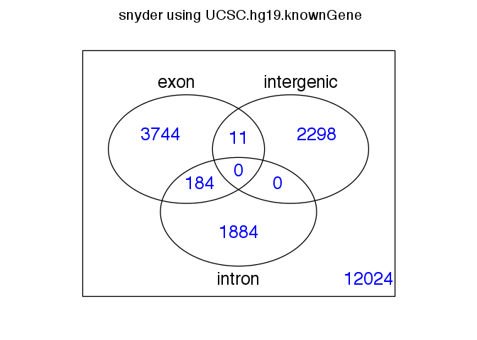

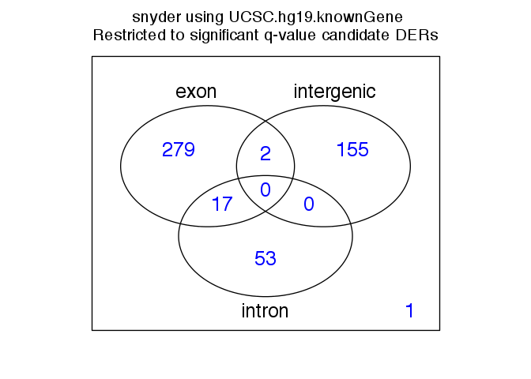

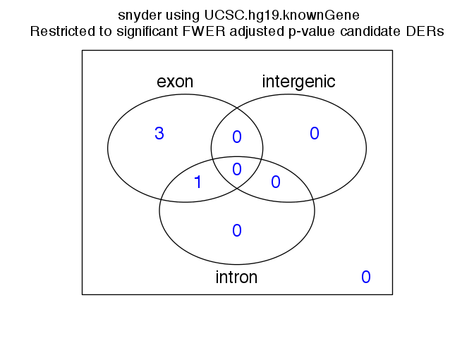

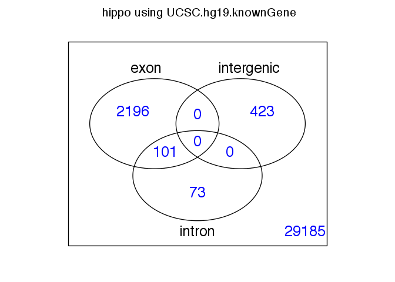

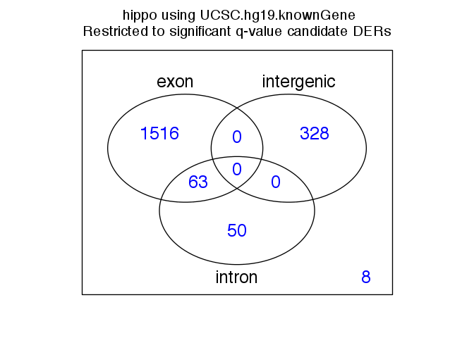

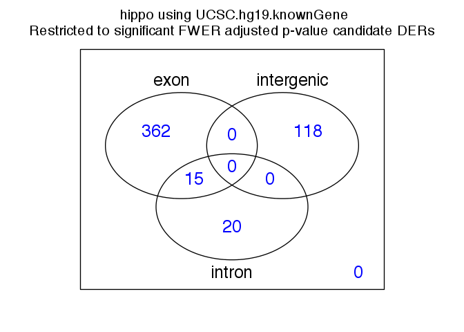

# 2 Details

The supplementary files 1 and 2 contain the information for the candidate DERs found in [CSV](http://en.wikipedia.org/wiki/Comma-separated_values) format. The CSV files contain the following columns:

1. **seqnames** The chromosome name.
2. **start** The position of the chromosome where the candidate DER begins.
3. **end** The position of the chromosome where the candidate DER ends.
4. **width** The width of the candidate DER.
5. **strand** The strand of the candidate DER.
6. **value** The mean of the F-statistics for the candidate DER.
7. **area** The sum of the F-statistics for the candidate DER.
8. **indexStart** Among the bases from the chromosome that passed the filtering step, the position where the candidate DER begins.
9. **indexEnd** Among the bases from the chromosome that passed the filtering step, the position where the candidate DER ends.
10. **cluster** The cluster number to which the candidate DER belongs to. Clusters were defined by chromosome and two candidate DERs belong to the same cluster if they are less than 3000 bp apart.
11. **clusterL** The length of the cluster to which the candidate DER belongs to.
12. **meanCoverage** The mean coverage among all samples for the candidate DER.
13. *mean__G__* The mean coverage among the samples of group **G** for the candidate DER.
14. *log2FoldChange__G1__.vs__G2__* The log2 fold change between the samples in **G1** and the samples in **G2** for the candidate DER.
15. **pvalues** The p-value for the candidate DER. It is calculated empirically using the null candidate DERs (obtained via permutations) from all chromosomes.
16. **significant** Whether the p-value is less than 0.05.
17. **qvalues** The p-value adjusted to control the FDR by using the `qvalue` ([with contributions from Andrew J. Bass, Dabney, and Robinson, 2015](http://github.com/jdstorey/qvalue)) function from the package with the same name.
18. **significantQval** Whether the q-value is less than 0.10.
19. **name** This and the following fields are computed using `annotateNearest()` from the `bumphunter` package. They were calculated using the UCSC hg19 annotation. **name** refers to the nearest gene.
20. **annotation** RefSeq ID. Taken from the help page of `bumphunter::annotateNearest()`.
21. **description** A factor with levels *upstream*, *promoter*, *overlaps 5’*, *inside intron*, *inside exon*, *covers exon(s)*, *overlaps exon upstream*, *overlaps exon downstream*, *overlaps two exons*, *overlaps 3’*, *close to 3’*, *downstream*, *covers*. Taken from the help page of `bumphunter::annotateNearest()`.
22. **region** A factor with levels *upstream*, *promoter*, *overlaps 5’*, *inside*, *overlaps 3’*, *close to 3’*, *downstream*, *covers*. Taken from the help page of `bumphunter::annotateNearest()`.
23. **subregion** A factor with levels *inside intron*, *inside exon*, *covers exon(s)*, *overlaps exon upstream*, *overlaps exon downstream*, *overlaps two exons*. Taken from the help page of `bumphunter::annotateNearest()`.
24. **insidedistance** Distance past 5 prime end of gene. Taken from the help page of `bumphunter::annotateNearest()`.
25. **exonnumber** Which exon. Taken from the help page of `bumphunter::annotateNearest()`.
26. **nexons** Number of exons. Taken from the help page of `bumphunter::annotateNearest()`.
27. **UTR** A factor with levels *inside transcription region*, *5’ UTR*, *overlaps 5’ UTR*, *3’ UTR*, *overlaps 3’ UTR*, *covers transcription region*. Taken from the help page of `bumphunter::annotateNearest()`.
28. **annoStrand** + or -. Taken from the help page of `bumphunter::annotateNearest()`.
29. **geneL** The gene length. Taken from the help page of `bumphunter::annotateNearest()`.
30. **codingL** The coding length. Taken from the help page of `bumphunter::annotateNearest()`.
31. **fwer** The FWER adjusted p-value for the region.
32. **significantFWER** Whether the FWER adjusted p-value is less than 0.05.

# 3 Reproducibility

Date the report was generated.

```
## [1] "2016-02-20 10:27:43 EST"
```

Wallclock time spent generating the report.

```
## Time difference of 21.416 secs
```

```
##  setting  value
##  version  R version 3.2.2 (2015-08-14)
##  system   x86_64, darwin13.4.0
##  ui       X11
##  language (EN)
##  collate  en_US.UTF-8
##  tz       America/New_York
##  date     2016-02-20
```

```
## Packages ---------------------------------------------------------------------------------------------------------------
```

```
##  package              * version  date       source
##  acepack                1.3-3.3  2014-11-24 CRAN (R 3.2.0)
##  AnnotationDbi          1.32.3   2015-12-24 Bioconductor
##  bibtex                 0.4.0    2014-12-31 CRAN (R 3.2.0)
##  Biobase                2.30.0   2015-10-14 Bioconductor
##  BiocGenerics         * 0.16.1   2015-11-06 Bioconductor
##  BiocInstaller          1.20.1   2015-11-18 Bioconductor
##  BiocParallel           1.4.3    2015-12-16 Bioconductor
##  BiocStyle            * 1.8.0    2015-10-14 Bioconductor
##  biomaRt                2.26.1   2015-11-23 Bioconductor
##  Biostrings             2.38.3   2016-01-02 Bioconductor
##  biovizBase             1.18.0   2015-10-14 Bioconductor
##  bitops                 1.0-6    2013-08-17 CRAN (R 3.2.0)
##  BSgenome               1.38.0   2015-10-14 Bioconductor
##  bumphunter             1.10.0   2015-10-14 Bioconductor
##  Cairo                  1.5-9    2015-09-26 CRAN (R 3.2.0)
##  cluster                2.0.3    2015-07-21 CRAN (R 3.2.2)
##  codetools              0.2-14   2015-07-15 CRAN (R 3.2.2)
##  colorspace             1.2-6    2015-03-11 CRAN (R 3.2.0)
##  DBI                    0.3.1    2014-09-24 CRAN (R 3.2.0)
##  derfinder            * 1.5.19   2015-12-15 Bioconductor
##  derfinderHelper        1.4.1    2015-11-03 Bioconductor
##  derfinderPlot        * 1.4.1    2015-11-03 Bioconductor
##  devtools               1.10.0   2016-01-23 CRAN (R 3.2.3)
##  dichromat              2.0-0    2013-01-24 CRAN (R 3.2.0)
##  digest                 0.6.9    2016-01-08 CRAN (R 3.2.3)
##  doRNG                  1.6      2014-03-07 CRAN (R 3.2.0)
##  evaluate               0.8      2015-09-18 CRAN (R 3.2.0)
##  foreach                1.4.3    2015-10-13 CRAN (R 3.2.0)
##  foreign                0.8-66   2015-08-19 CRAN (R 3.2.0)
##  formatR                1.2.1    2015-09-18 CRAN (R 3.2.0)
##  Formula                1.2-1    2015-04-07 CRAN (R 3.2.0)
##  futile.logger          1.4.1    2015-04-20 CRAN (R 3.2.0)
##  futile.options         1.0.0    2010-04-06 CRAN (R 3.2.0)
##  GenomeInfoDb         * 1.6.3    2016-01-26 Bioconductor
##  GenomicAlignments      1.6.3    2016-01-06 Bioconductor
##  GenomicFeatures        1.22.12  2016-01-28 Bioconductor
##  GenomicFiles           1.6.2    2015-12-30 Bioconductor
##  GenomicRanges        * 1.22.4   2016-01-30 Bioconductor
##  GGally                 1.0.1    2016-01-14 CRAN (R 3.2.3)
```

[output cut: 41 more lines]

```
##  Rsamtools              1.22.0   2015-10-14 Bioconductor
##  RSQLite                1.0.0    2014-10-25 CRAN (R 3.2.0)
##  rtracklayer            1.30.1   2015-10-22 Bioconductor
##  S4Vectors            * 0.8.11   2016-01-29 Bioconductor
##  scales                 0.3.0    2015-08-25 CRAN (R 3.2.0)
##  stringi                1.0-1    2015-10-22 CRAN (R 3.2.0)
##  stringr                1.0.0    2015-04-30 CRAN (R 3.2.0)
##  SummarizedExperiment   1.0.2    2016-01-01 Bioconductor
##  survival               2.38-3   2015-07-02 CRAN (R 3.2.2)
##  VariantAnnotation      1.16.4   2015-12-09 Bioconductor
##  XML                    3.98-1.3 2015-06-30 CRAN (R 3.2.0)
##  xtable                 1.8-0    2015-11-02 CRAN (R 3.2.0)
##  XVector                0.10.0   2015-10-14 Bioconductor
##  yaml                   2.1.13   2014-06-12 CRAN (R 3.2.0)
##  zlibbioc               1.16.0   2015-10-14 Bioconductor
```

# 4 Bibliography

This report was generated using `BiocStyle` ([Morgan, Oleś, and Huber, 2016](https://github.com/Bioconductor/BiocStyle)) with `knitr` ([Xie, 2014](http://www.crcpress.com/product/isbn/9781466561595)) and `rmarkdown` ([Allaire, Cheng, Xie, McPherson, et al., 2016](http://CRAN.R-project.org/package=rmarkdown)) running behind the scenes.

Citations made with `knitcitations` ([Boettiger, 2015](http://CRAN.R-project.org/package=knitcitations)). Citation file: venn.bib.

[1] J. Allaire, J. Cheng, Y. Xie, J. McPherson, et al. *rmarkdown: Dynamic Documents for R*. R package version 0.9.2. 2016. URL: http://CRAN.R-project.org/package=rmarkdown.

[2] J. D. S. with contributions from Andrew J. Bass, A. Dabney and D. Robinson. *qvalue: Q-value estimation for false discovery rate control*. R package version 2.2.2. 2015. URL: http://github.com/jdstorey/qvalue.

[3] C. Boettiger. *knitcitations: Citations for ‘Knitr’ Markdown Files*. R package version 1.0.7. 2015. URL: http://CRAN.R-project.org/package=knitcitations.

[4] L. Collado-Torres, A. C. Frazee, M. I. Love, R. A. Irizarry, et al. “derfinder: Software for annotation-agnostic RNA-seq differential expression analysis”. In: *bioRxiv* (2015). DOI: 10.1101/015370. URL: http://www.biorxiv.org/content/early/2015/02/19/015370.abstract.

[5] L. Collado-Torres, A. E. Jaffe and J. T. Leek. *derfinderPlot: Plotting functions for derfinder*. https://github.com/leekgroup/derfinderPlot - R package version 1.4.1. 2015. URL: http://www.bioconductor.org/packages/release/bioc/html/derfinderPlot.html.

[6] M. Morgan, A. Oleś and W. Huber. *BiocStyle: Standard styles for vignettes and other Bioconductor documents*. R package version 1.8.0. 2016. URL: https://github.com/Bioconductor/BiocStyle.

[7] Y. Xie. “knitr: A Comprehensive Tool for Reproducible Research in R”. In: *Implementing Reproducible Computational Research*. Ed. by V. Stodden, F. Leisch and R. D. Peng. ISBN 978-1466561595. Chapman and Hall/CRC, 2014. URL: http://www.crcpress.com/product/isbn/9781466561595.